# Los pingüinos de Palmer

Un ejemplo de uso de Quarto

Autor/a

Afiliación

Jesus M. Castagnetto, Ph.D.

INSIGHT / UPCH

**Código**

```r
# cargar las librerías que necesitamos
library(tidyverse)
library(knitr)
library(palmerpenguins)
```

## Introducción

Este es un ejemplo de un reporte sencillo, en formato HTML, generado usando Quarto.

Vamos a usar los datos de pingüinos del archipiélago de Palmer (Antártica), que fueron originalmente recolectados por la **Dra. Kristen Gorman**, como parte del *Programa de Investigación Ecológica de Largo Plazo* de la Estación Palmer (LTER: Long Term Ecological Research).

Estos datos incluyen medidas anatómicas, pesos, y otros parámetros de pingüinos adultos de las especies Adélie, Chinstrap y Gentoo, en las áreas cercanas a la Estación Palmer.

El conjunto de datos está disponible como un paquete de R: [palmerpenguins](https://allisonhorst.github.io/palmerpenguins/), a través del esfuerzo de [Allison Horst](https://www.allisonhorst.com/), [Alison Hill](https://www.apreshill.com/) y [Kristen Gorman](https://www.uaf.edu/cfos/people/faculty/detail/kristen-gorman.php). En las siguientes secciones vamos a usar estos datos para ilustrar la creación de una tabla simple, y un par de gráficos.

A continuación podemos observar un resúmen de la estructura de los datos:

**Código**

```r
glimpse(penguins)
```

```
Rows: 344
Columns: 8
$ species           <fct> Adelie, Adelie, Adelie, Adelie, Adelie, Adelie, Adel…
$ island            <fct> Torgersen, Torgersen, Torgersen, Torgersen, Torgerse…
$ bill_length_mm    <dbl> 39.1, 39.5, 40.3, NA, 36.7, 39.3, 38.9, 39.2, 34.1, …
$ bill_depth_mm     <dbl> 18.7, 17.4, 18.0, NA, 19.3, 20.6, 17.8, 19.6, 18.1, …
$ flipper_length_mm <int> 181, 186, 195, NA, 193, 190, 181, 195, 193, 190, 186…
$ body_mass_g       <int> 3750, 3800, 3250, NA, 3450, 3650, 3625, 4675, 3475, …
$ sex               <fct> male, female, female, NA, female, male, female, male…
$ year              <int> 2007, 2007, 2007, 2007, 2007, 2007, 2007, 2007, 2007…
```

Estos datos tienen 8 columnas, y 344 registros de pingüinos, que fueron encontrados en 3 islas: Biscoe, Dream, Torgersen

## Estadísticas de los pinguinos por especie y sexo

Vamos a crear un par de tablas resumiendo los datos que tenemos de los pingüinos, para lo cual calcularemos, para cada combinación de especie y sexo, el total de individuos registrados, el número de islas en los que aparecen, así como los promedios y desviaciones estándar de: la longitud del pico y la aleta, de la profundidad del pico, y del peso de los pingüinos.

**Código**

```r
esp_sexo <- penguins %>%
  group_by(
    species,
    sex
  ) %>%
  summarise(
    total = n(),
    n_islas = n_distinct(island),
    prom_long_pico = mean(bill_length_mm, na.rm = TRUE),
    sd_long_pico = sd(bill_length_mm, na.rm = TRUE),
    prom_prof_pico = mean(bill_depth_mm, na.rm = TRUE),
    sd_prof_pico = sd(bill_depth_mm, na.rm = TRUE),
    prom_long_ala = mean(flipper_length_mm, na.rm = TRUE),
    sd_long_ala = sd(flipper_length_mm, na.rm = TRUE),
    prom_peso = mean(body_mass_g, na.rm = TRUE),
    sd_peso = sd(body_mass_g, na.rm = TRUE)
  ) %>%
  ungroup() %>%
  mutate(  # Cambiar los contenidos al español
    sex = case_when(
        sex == "male" ~ "Masculino",
        sex == "female" ~ "Femenino",
        is.na(sex) ~ "Desconocido"
      )
  )
```

Los datos agregados, vamos a arreglarlos de tal manera que podamos crear un par de tablas:

1. La primera, mostrando para cada combinación de especie y sexo, el número de individuos y en cuantas islas se encuentran.
2. Una segunda en la que se tengan las medidas numéricas en la forma: *promedio (desv. estándar)*, y todas con un sólo decimal de precisión.

**Código**

```r
# Usemos mutate() para crear nuevas columnas en el formato que queremos
tab_pinguinos <- esp_sexo %>%
  mutate(
    long_pico = paste(
      round(prom_long_pico, 1),
      " (",
      round(sd_long_pico, 1),
      ")"
    ),
    prof_pico = paste(
      round(prom_prof_pico, 1),
      " (",
      round(sd_prof_pico, 1),
      ")"
    ),
    long_ala = paste(
      round(prom_long_ala, 1),
      " (",
      round(sd_long_ala, 1),
      ")"
    ),
    peso = paste(
      round(prom_peso, 1),
      " (",
      round(sd_peso, 1),
      ")"
    )
  ) %>%
  select( # seleccionar y renombrar las columnas
    Especie = species,
    Sexo = sex,
    Total = total,
    Islas = n_islas,
    "Pico (long)" = long_pico,
    "Pico (prof)" = prof_pico,
    Aleta = long_ala,
    Peso = peso
  )
```

La tabla de distribución por especie y sexo

**Código**

```r
# tabla 1
kable(
  tab_pinguinos %>%
    select(Especie, Sexo, Total, Islas)
)
```

| Especie | Sexo | Total | Islas |
| --- | --- | --- | --- |
| Adelie | Femenino | 73 | 3 |
| Adelie | Masculino | 73 | 3 |
| Adelie | Desconocido | 6 | 2 |
| Chinstrap | Femenino | 34 | 1 |
| Chinstrap | Masculino | 34 | 1 |
| Gentoo | Femenino | 58 | 1 |
| Gentoo | Masculino | 61 | 1 |
| Gentoo | Desconocido | 5 | 1 |

Y la tabla de distribución de las medidas numéricas

**Código**

```r
# tabla 2
kable(
  tab_pinguinos %>%
    select(-Total, -Islas)
)
```

| Especie | Sexo | Pico (long) | Pico (prof) | Aleta | Peso |
| --- | --- | --- | --- | --- | --- |
| Adelie | Femenino | 37.3 ( 2 ) | 17.6 ( 0.9 ) | 187.8 ( 5.6 ) | 3368.8 ( 269.4 ) |
| Adelie | Masculino | 40.4 ( 2.3 ) | 19.1 ( 1 ) | 192.4 ( 6.6 ) | 4043.5 ( 346.8 ) |
| Adelie | Desconocido | 37.8 ( 2.8 ) | 18.3 ( 1.3 ) | 185.6 ( 6.1 ) | 3540 ( 477.2 ) |
| Chinstrap | Femenino | 46.6 ( 3.1 ) | 17.6 ( 0.8 ) | 191.7 ( 5.8 ) | 3527.2 ( 285.3 ) |
| Chinstrap | Masculino | 51.1 ( 1.6 ) | 19.3 ( 0.8 ) | 199.9 ( 6 ) | 3939 ( 362.1 ) |
| Gentoo | Femenino | 45.6 ( 2.1 ) | 14.2 ( 0.5 ) | 212.7 ( 3.9 ) | 4679.7 ( 281.6 ) |
| Gentoo | Masculino | 49.5 ( 2.7 ) | 15.7 ( 0.7 ) | 221.5 ( 5.7 ) | 5484.8 ( 313.2 ) |
| Gentoo | Desconocido | 45.6 ( 1.4 ) | 14.6 ( 0.8 ) | 215.8 ( 1.3 ) | 4587.5 ( 338.2 ) |

## Ejemplos de gráficos

Con los datos originales, vamos ahora a crear un par de gráficos sencillos, uno de barras y otro de dispersión.

### Gráfico de barras

Primero, vamos a mostrar la distribución del número de pingüinos registrados por cada especie e isla. Coloreando los segmentos de las barras usan la isla en que fueron encontrados.

**Código**

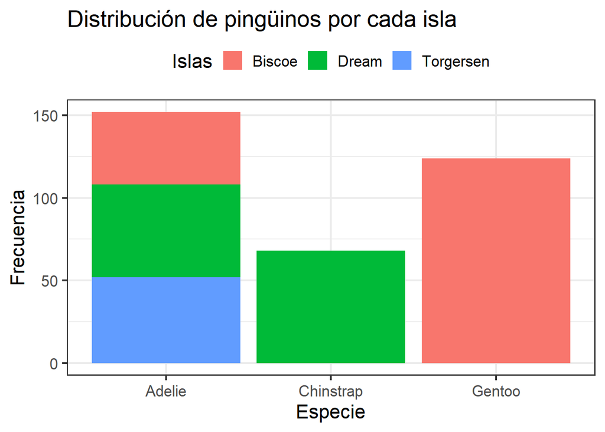

```r
ggplot(
  penguins,
  aes(x = species, fill = island)
) +
  geom_bar() +
  labs(
    title = "Distribución de pingüinos por cada isla",
    x = "Especie",
    y = "Frecuencia",
    fill = "Islas"
  ) +
  theme_bw(16) +
  theme(
    legend.position = "top"
  )
```

### Gráfico de dispersión

Y para nuestro segundo (y último) gráfico, observemos cual es la correlación entre las longitudes (en mm) de los picos y aletas de los pingüinos, coloreando cada punto por la especie a la que pertenecen.

Usaremos una escala de colores que sea amigable a quienes tienen daltonismo (“Paired”)[^1]

**Código**

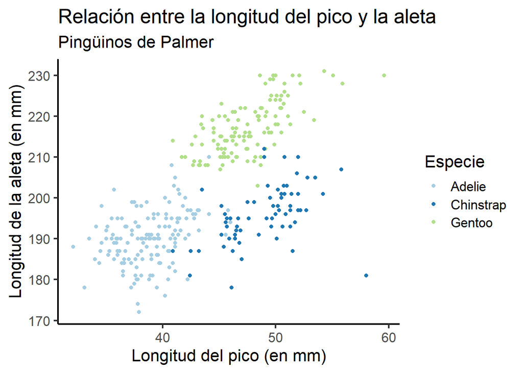

```r
ggplot(
  penguins,
  aes(x = bill_length_mm,
      y = flipper_length_mm,
      color = species)
) +
  geom_point() +
  scale_color_brewer(palette = "Paired") +
  labs(
    title = "Relación entre la longitud del pico y la aleta",
    subtitle = "Pingüinos de Palmer",
    x = "Longitud del pico (en mm)",
    y = "Longitud de la aleta (en mm)",
    color = "Especie"
  ) +
  theme_classic(16)
```

## Notas

[^1]: Otras escalas se pueden explorar en https://colorbrewer2.org/